# CSCI E-25

## Independent Project - Fashion Classifier

## Introduction

This project aims to classify photos of pieces of clothing and analyze their colors, patterns and textures. Unfortunately, a plethora of technical problems precluded the implementation of the entire system due to problems with classification in the first stage.

The first stage requires importing machine learning packages and support packages for data processing.

```python
import tensorflow as tf
import tensorflow.keras as keras
import numpy as np
import matplotlib.pyplot as plt
import random

from keras.utils import to_categorical

# IMG_SIZE means the number of pixels on each side of an image in the neural net.
IMG_SIZE = 28
BATCH_SIZE = 1024
```

IMG_SIZE is, as mentioned, the size of a side. In pixel terms, one pixel represents a point of color, in red-green-blue levels.

```python
print(tf.__version__)
```

```
2.12.0
```

```python
gpu = len(tf.config.list_physical_devices('GPU'))>0
print("GPU is", "available" if gpu else "NOT AVAILABLE")
```

```
GPU is available
```

Having verified our TensorFlow version, we can now load the Fashion-MNIST dataset, build a classifer, and train it. Fashion-MNIST is a set of labeled pieces of clothing, with a pixel size of 28x28 pixels. This is the reason why IMG_SIZE is 28 pixels per side.

```python
fmnist = tf.keras.datasets.fashion_mnist
(train_images, train_labels), (test_images, test_labels) = fmnist.load_data()
```

```python
train_labels
```

```
array([9, 0, 0, ..., 3, 0, 5], dtype=uint8)
```

We have ten classes in the dataset. However, the names are not stored in the dataset, but instead correspond to a numerical label 0-9.

```python
class_names = ['T-shirt/top', 'Trouser', 'Pullover', 'Dress', 'Coat',
               'Sandal', 'Shirt', 'Sneaker', 'Bag', 'Ankle boot']
```

Before building and training our classifier, we must explore the data.

```python
train_images.shape
```

```
(60000, 28, 28)
```

Our training data consists of 60,000 images of 28x28 pixels.

```python
test_images.shape
```

```
(10000, 28, 28)
```

Our test set is much smaller, containing 10,000 images of 28x28 pixels. We will now view a small sample of our fashion images for both our train and test data:

```
Training Images:
```

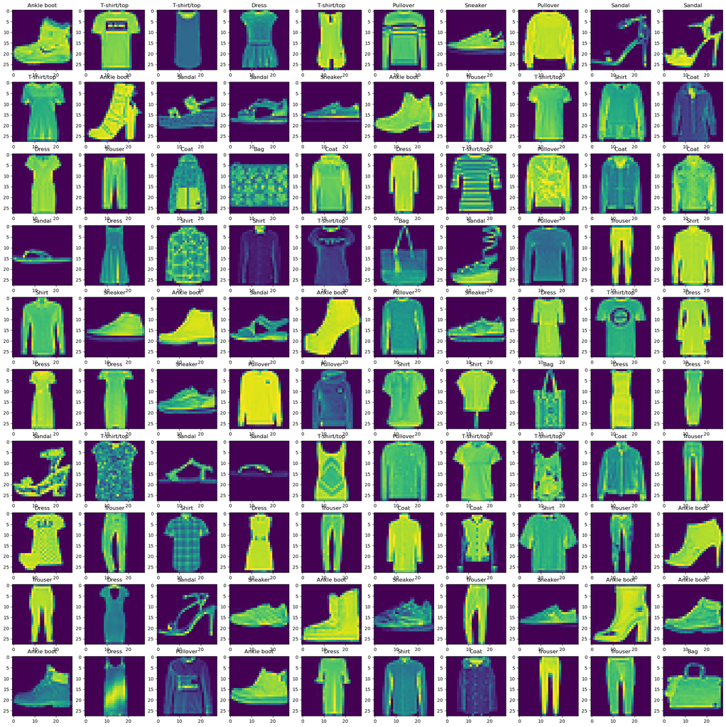

```python
fig, ax = plt.subplots(10, 10, figsize=(28,28))
ax = ax.flatten()

print("Training Images:")

for i in range(0, 100):
        img = train_images[i]
        if img is None:
            continue

        label = class_names[train_labels[i]]
        ax[i].imshow(img)
        ax[i].set_title(label)
```

```
Test Images:
```

[figure not shown]

```python
fig, ax = plt.subplots(10, 10, figsize=(28,28))
ax = ax.flatten()

print("Test Images:")

for i in range(0, 100):
        img = test_images[i]
        if img is None:
            continue

        label = class_names[test_labels[i]]
        ax[i].imshow(img)
        ax[i].set_title(label)
```

Before setting up the neural net, it is now time to preprocess our images for feature extraction, with each range being set to a 0-1.0 float.

```python
train_images = train_images / 255.0
test_images = test_images / 255.0
```

```python
# Grayscale to RGB conversion.
train_images = tf.image.grayscale_to_rgb(tf.expand_dims(train_images, axis=-1)).numpy()
test_images = tf.image.grayscale_to_rgb(tf.expand_dims(test_images, axis=-1)).numpy()
```

First, we check that we have 60,000 training images and 10,000 testing images, all of 28x28 pixels with 3 color channels for red, green, and blue.

```python
# Verify shape
train_images.shape, test_images.shape
```

```
((60000, 28, 28, 3), (10000, 28, 28, 3))
```

In the tuples above, the first number represents the number of images for training and testing, the next two represent image dimensions (width x height), and the last number represents color channels (3 channels for RGB).

```python
train_labels.shape, test_labels.shape
```

```
((60000,), (10000,))
```

We must check image information in a small sample of randomly-selected images.

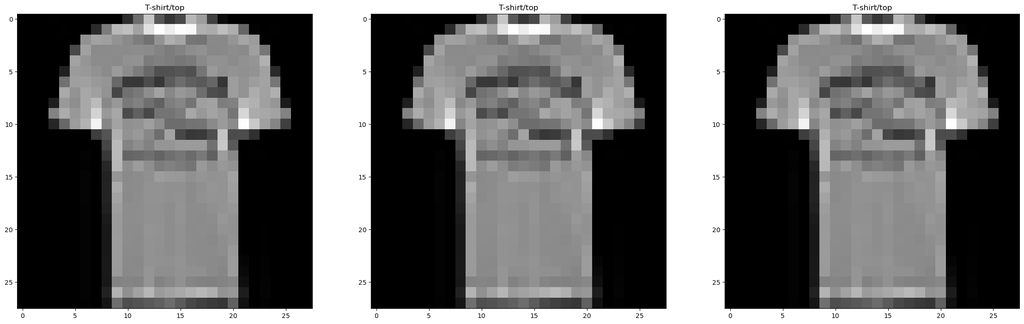

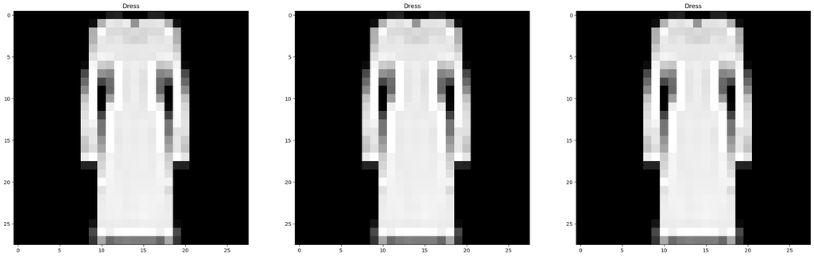

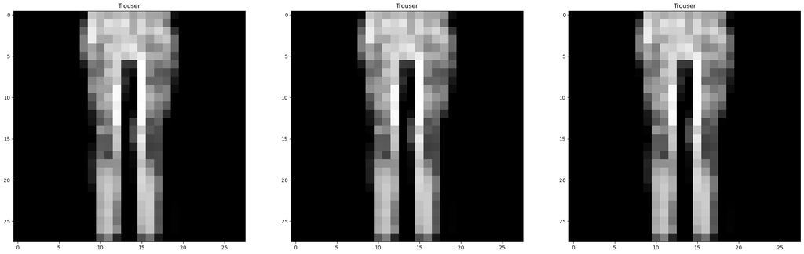

```python
def show_random_image(side=28):
    fig, ax = plt.subplots(1, 3, figsize=(side,side))
    ax = ax.flatten()

    idx = random.randint(0, 60000)

    for i in range(0, 3):
        img = train_images[idx,:,:,i]
        if img is None:
            continue

        ax[i].imshow(img, cmap=plt.get_cmap('gray'))
        label = class_names[train_labels[idx]]
        ax[i].set_title(label)

show_random_image()
show_random_image()
show_random_image()
```

For all of our data, we will be using a simple network as per the tutorial at https://www.tensorflow.org/tutorials/keras/classification. We must also import additional TensorFlow support packages for the neural net layers.

```python
from keras import layers
from tensorflow.keras.models import Sequential, Model
```

```python
model = tf.keras.Sequential([
    tf.keras.layers.Flatten(input_shape=(IMG_SIZE, IMG_SIZE,3)),
    tf.keras.layers.Dense(128, activation='relu'),
    tf.keras.layers.Dense(10)
])

model.compile(optimizer='adam',
              loss=tf.keras.losses.CategoricalCrossentropy(from_logits=True),
              metrics=['accuracy'])
```

```python
model.summary()
```

```
Model: "sequential"
_________________________________________________________________
 Layer (type)                Output Shape              Param #
=================================================================
 flatten (Flatten)           (None, 2352)              0

 dense (Dense)               (None, 128)               301184

 dense_1 (Dense)             (None, 10)                1290

=================================================================
Total params: 302,474
Trainable params: 302,474
Non-trainable params: 0
_________________________________________________________________
```

Categorical encoding changes text (such as "T-Shirt", "Dress", etc) to 0 or 1 based on whether an image is or isn't part of a class specified in Fashion-MNIST.

```python
train_labels = to_categorical(train_labels)
```

```python
test_labels = to_categorical(test_labels)
```

In addition, each image must be resized to our image size to allow for improved shape detection further down.

```python
# Train the model
model.fit(train_images,
                  train_labels,
                  epochs=10
                  )
```

```
2024-05-09 16:37:15.464498: W tensorflow/tsl/platform/profile_utils/cpu_utils.cc:128] Failed to get CPU frequency: 0 Hz
```

```
<keras.callbacks.History at 0x3154a5410>
```

```python
# Evaluate model accuracy
test_loss, test_acc = model.evaluate(test_images,  test_labels, verbose=2)
print('Test accuracy:', test_acc)
```

```
313/313 - 2s - loss: 0.8411 - accuracy: 0.7934 - 2s/epoch - 5ms/step
Test accuracy: 0.79339998960495
```

```python
def plot_hist(hist):
    _,ax = plt.subplots(1,2, figsize = (12,6))
    ax[0].plot(hist.history["accuracy"])
    ax[0].plot(hist.history["val_accuracy"])
    ax[0].set_title("model accuracy")
    ax[0].set_ylabel("accuracy")
    ax[0].set_xlabel("epoch")
    ax[0].legend(["train", "validation"], loc="upper left")
    ax[1].plot(hist.history["loss"])
    ax[1].plot(hist.history["val_loss"])
    ax[1].set_title("model loss")
    ax[1].set_ylabel("loss")
    ax[1].set_xlabel("epoch")
    ax[1].legend(["train", "validation"], loc="upper right")
    plt.show()
```

Training and testing predictions will now be made on the preprocessed data using Sequential network. Trained data will then be saved for future use.

```python
model.fit(train_images,
                  train_labels,
                  epochs=20
         )
```

```
<keras.callbacks.History at 0x315253410>
```

```python
probability_model = tf.keras.Sequential([model,
                                         tf.keras.layers.Softmax()])
```

```python
# Extraction stage
train_features = model.predict(np.array(train_images), batch_size=BATCH_SIZE, verbose=1)
test_features = model.predict(np.array(test_images), batch_size=BATCH_SIZE, verbose=1)

# Feature saving stage
np.savez("train_features", train_features, train_labels)
np.savez("test_features", test_features, test_labels)
```

```python
# Extraction stage
train_features = model.predict(np.array(train_images), batch_size=BATCH_SIZE, verbose=1)
test_features = model.predict(np.array(test_images), batch_size=BATCH_SIZE, verbose=1)

# Feature saving stage
np.savez("train_features", train_features, train_labels)
np.savez("test_features", test_features, test_labels)
```

It is now time to load a set of real-world use case images for classification and further processing.

```python
import skimage
from skimage import data
from skimage.filters.rank import equalize
import skimage.filters as skfilters
import skimage.morphology as morphology
import skimage.transform as transform
from skimage.color import rgb2gray, gray2rgb
from skimage import exposure
from PIL import Image
import numpy as np
import math
import matplotlib.pyplot as plt
import os
%matplotlib inline
```

```python
def plot_grayscale(img, h=8, axis='off'):
    plt.figure(figsize=(h, h))
    plt.title = "Grayscale"
    _=plt.imshow(img, cmap=plt.get_cmap('gray'))
    _=plt.axis(axis);
```

```python
def plot_value_array(i, predictions_array):
    plt.grid(False)
    plt.xticks(range(10), class_names, rotation=45)
    plt.show()
    plt.yticks([])

    for i in range(0, len(predictions_array)):
        label = predictions_array[i]
        thisplot = plt.bar(range(10), label, color="#777777")
        plt.ylim([0, 1])
        predicted_label = label
        thisplot[i].set_color('red')
```

```python
def plot_color_image(img):
    fig, ax = plt.subplots( figsize=(6, 6))
    _=ax.imshow(img)
```

```python
def predict_piece(image_url):
    img_np = np.asarray(Image.open(image_url))

    print('The image object is ' + str(type(img_np)))
    print('The pixel values are of type ' + str(type(img_np[0,0,0])))
    print('Shape of image object = ' + str(img_np.shape))

    print('Original Image')
    plot_color_image(img_np)

    img_name = os.path.splitext(os.path.basename(image_url))[0]
    img_path = tf.keras.utils.get_file(img_name,
                                       origin='file://' + os.path.abspath(image_url))

    img = tf.keras.utils.load_img(
        img_path, target_size=(img_np.shape[1], img_np.shape[0])
    ).resize((IMG_SIZE,IMG_SIZE))

    print('Shrunken Image')
    plot_color_image(img)

    grayscale = gray2rgb(rgb2gray(img))
    grayscale = exposure.equalize_adapthist(grayscale)

    print('Equalized histogram')
    plot_grayscale(grayscale)

    img_array = tf.expand_dims(grayscale, 0) # Create a batch of a single image
    print(img_array.shape)

    predictions = probability_model.predict(img_array)
    print(predictions.shape)

    plot_value_array(1, predictions)

    class_id = np.argmax(predictions, axis = 1)
    print("Most Likely Match: {}".format(class_names[class_id[0]]))

    score = predictions[0][class_id[0]]

    print(
        "This piece is most likely a {} with a {:.2f} percent confidence."
        .format(class_names[class_id[0]], 100 * np.max(score))
    )
```

Unfortunately, the images become extremely hard to determine when resized down to the size of the training images. Because sizing the training images to a larger size causes severe accuracy problems, resizing doesn't solve the problem.

```
The image object is <class 'numpy.ndarray'>
The pixel values are of type <class 'numpy.uint8'>
Shape of image object = (4032, 3024, 3)
Original Image
Shrunken Image
Equalized histogram
(1, 28, 28, 3)
(1, 10)
```

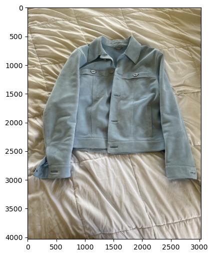

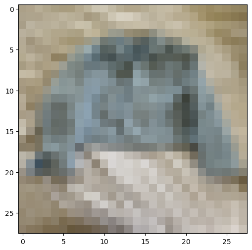

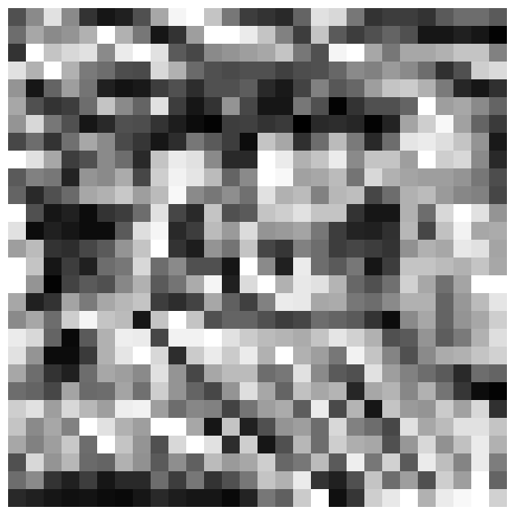

```
Most Likely Match: Bag
This piece is most likely a Bag with a 100.00 percent confidence.
```

```python
predict_piece('images/blue_jacket.png')
```

In the example above, the lines of the jacket's sleeves and other defining characteristics are lost to resizing. This means the neural net classified it as a bag because of its general shape. Moreover, the equalized histogram, which is the pixelated black and white image, cannot really be determined to be anything. As a result, all classifications and accuracy are far below par in all attempts at piece classification.

```
The image object is <class 'numpy.ndarray'>
The pixel values are of type <class 'numpy.uint8'>
Shape of image object = (4032, 3024, 3)
Original Image
Shrunken Image
Equalized histogram
(1, 28, 28, 3)
(1, 10)
```

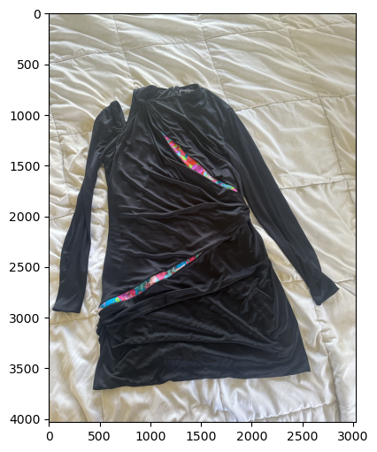

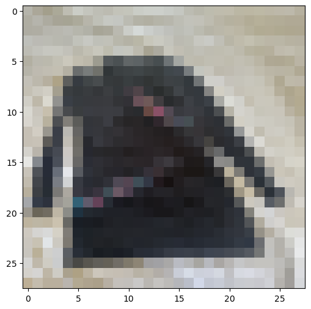

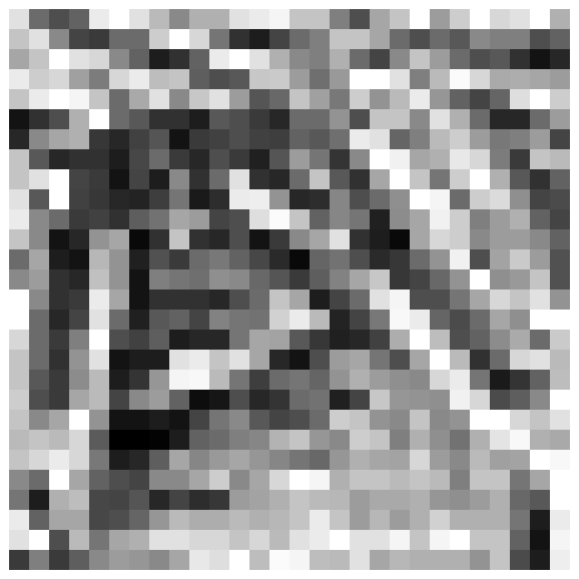

```
Most Likely Match: Bag
This piece is most likely a Bag with a 100.00 percent confidence.
```

```python
predict_piece('images/black_highlight_dress.png')
```

The exact same problems can be found here at a far worse level and are consistently found in all further attempts at piece classification. The downsized image still clearly shows the dress and some of the pattern, but once it's converted to grayscale and contrast-adjusted it becomes pure noise.

```
The image object is <class 'numpy.ndarray'>
The pixel values are of type <class 'numpy.uint8'>
Shape of image object = (4032, 3024, 3)
Original Image
Shrunken Image
Equalized histogram
(1, 28, 28, 3)
(1, 10)
```

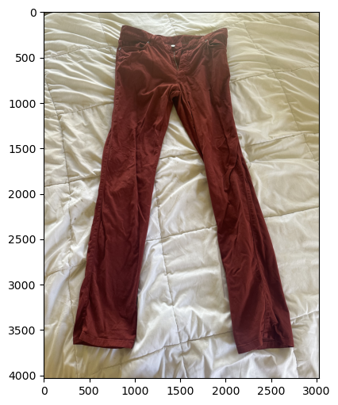

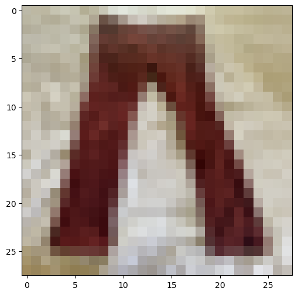

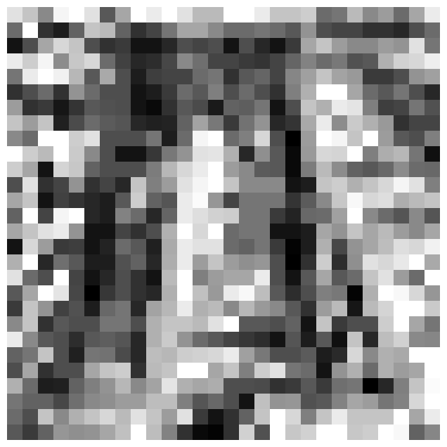

```
Most Likely Match: Bag
This piece is most likely a Bag with a 100.00 percent confidence.
```

```python
predict_piece('images/red_pants.png')
```

Here we find a particularly severe case of classification failing due to not taking color into account. Because the burgundy pants are still visible as what they are in the color image, it should be easy to find the shape. However, because the shape is found in a black and white image with adjusted contrast, there is a complete lack of a discernible shape due to grayscale information being barely distinguishable from noise. Thus, the classifier assumes it's a bag.

```
The image object is <class 'numpy.ndarray'>
The pixel values are of type <class 'numpy.uint8'>
Shape of image object = (4032, 3024, 3)
Original Image
Shrunken Image
Equalized histogram
(1, 28, 28, 3)
(1, 10)
```

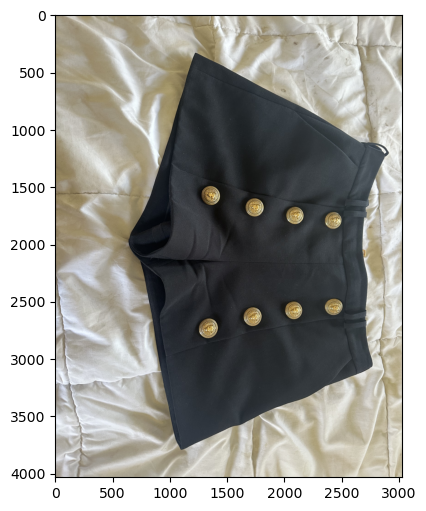

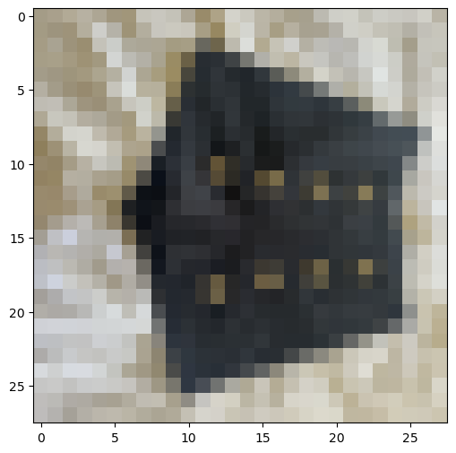

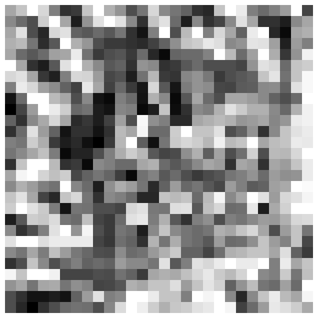

```
Most Likely Match: Bag
This piece is most likely a Bag with a 100.00 percent confidence.
```

```python
predict_piece('images/button_shorts.png')
```

```
The image object is <class 'numpy.ndarray'>
The pixel values are of type <class 'numpy.uint8'>
Shape of image object = (3024, 4032, 3)
Original Image
Shrunken Image
Equalized histogram
(1, 28, 28, 3)
(1, 10)
```

[figure not shown]

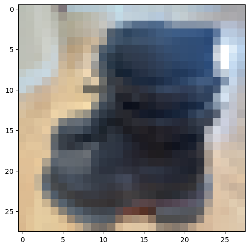

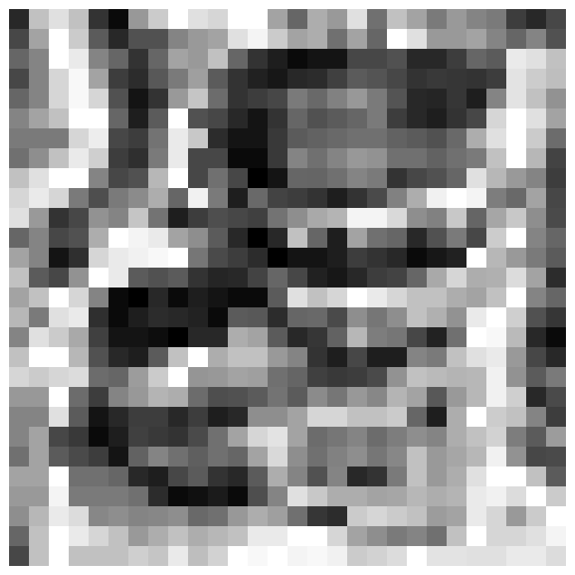

```
Most Likely Match: Bag
This piece is most likely a Bag with a 100.00 percent confidence.
```

```python
predict_piece('images/combat_boots.png')
```

```
The image object is <class 'numpy.ndarray'>
The pixel values are of type <class 'numpy.uint8'>
Shape of image object = (4032, 3024, 3)
Original Image
Shrunken Image
Equalized histogram
(1, 28, 28, 3)
(1, 10)
```

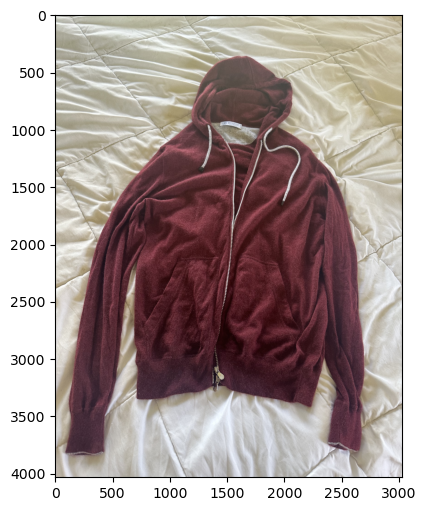

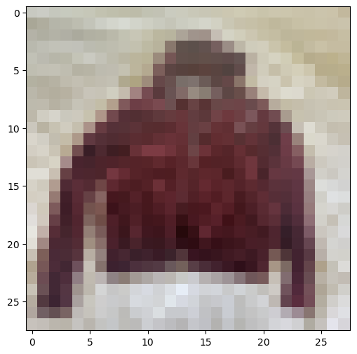

[figure not shown]

```
Most Likely Match: Bag
This piece is most likely a Bag with a 100.00 percent confidence.
```

```python
predict_piece('images/vino_hoodie.png')
```

In light of the failures seen above, the most likely solution for this project involves changing to training image set of a larger resolution instead of resizing small images. This should allow for improved accuracy even when using pretrained neural nets, which are trained on much larger sets of images and take in larger images for training than the images used in Fashion-MNIST.

In the future, once classification is implemented reliably, color evaluation can be performed by using vision transformers to find the shape and then analyzing the average color within the bounds of a shape. Similarly, vision transformers can be used to find shapes within shapes in order to determine if there is a pattern on a piece of clothing. Clothes can then be sorted by color or pattern.

A vision transformer is a system that breaks a large image into a grid of smaller, equal-sized images and analyzes each tile of the grid as well as the tiles together to find shapes.